# Single-Cell RNA-seq Analysis of normal gastric/BO/dysplasia organoids

Daniel Jacobson

2026-08-05

In this script, we will conduct analysis of single-cell RNA-seq of 24 organoids derived from six organoid lines. These lines include 2 normal gastric (one from gastric body, the other from GOJ), 2 Barrett oesophagus, and 2 derived from dysplasia. For each line, two different organoid culturing media were used (OWR and INC), and each had two replicates, resulting in 24 organoids total.

These organoids then underwent single-cell RNA-sequencing wiht on-chip multiplexing, and were processed using CellRanger adapted for OCM data.

The aims of this analysis are:

- To determine the cell types present in these organoids
- To demonstrate concordance between organoids of the same origins
- To show equivalence in cell populations depending on culture media

```r
library(tidyverse) # data frame manipulation
library(Seurat) # single cell analysis
```

```r
library(ggpubr) # plotting
library(ggridges) # ridgeplots
library(harmony) # batch correction for single cell data
```

# 1 Data Processing

## 1.1 Loading and processing

To begin with, we can load in the data and match it with our sample metadata and addition information.

```r
# Download the data here
se.filtered <- readRDS('Data/Data_run20260615_IlluminaSampleConvention/combined_filtered_matrix.seurat.rds')

# Match with sample IDs (from submission metadata) so that we can begin comparisons
yibing <- readxl::read_excel('../ScRNA-seq OCM submission sheet_Yibing.xlsx', skip=1) %>%
  dplyr::filter(tpye == 'organoid') # spelling mistake occurs within the metadata sheet

# Generate sample ID (combination of patient ID, origin, media, and number)
yibing$Sample.ID.full <- apply(yibing, 1, function(x) paste(x[c('Patient ID','Origin','treatement')], collapse='_'))

# Add sequencing metadata and merge
slx_contents <- read.csv('SLX-26391.23MVFCLT4.s_1.contents.csv') %>%
  mutate(OB1 = sapply(Sample.name, function(x) as.numeric(strsplit(strsplit(x, split=' ')[[1]][2], split='-')[[1]][1])),
         OB2 = sapply(Sample.name, function(x) as.numeric(strsplit(strsplit(x, split=' ')[[1]][2], split='-')[[1]][1])) + 1,
         OB3 = sapply(Sample.name, function(x) as.numeric(strsplit(strsplit(x, split=' ')[[1]][2], split='-')[[1]][1])) + 2,
         OB4 = sapply(Sample.name, function(x) as.numeric(strsplit(strsplit(x, split=' ')[[1]][2], split='-')[[1]][1])) + 3) %>%
  pivot_longer(cols = c(OB1, OB2, OB3, OB4), names_to = 'OB_value', values_to = 'Sample.ID')
slx_contents$Sequence.ID = apply(slx_contents, 1, function(x) paste(x[c('Pool','Barcode','OB_value')], collapse='_'))

yibing_slx <- merge(x = slx_contents, y = yibing, by.x = 'Sample.ID', by.y = 'Sample ID')
```

Let us now add the relevant information to the colData for se.filtered

```r
# Extract cell IDs
se.filtered$Cell.ID = sapply(names(se.filtered$sample), function(x) str_replace(x,'_filtered',''))
se.filtered$Sequence.ID = sapply(se.filtered$sample, function(x) str_replace(x,'_filtered',''))

# Patient information matched with Yibing's metadata
se.filtered$Patient.ID = yibing_slx$`Patient ID`[match(se.filtered$Sequence.ID, yibing_slx$Sequence.ID)]
se.filtered$Origin = yibing_slx$Origin[match(se.filtered$Sequence.ID, yibing_slx$Sequence.ID)]
se.filtered$Origin[se.filtered$Origin == 'BE'] <- 'NDBO'
se.filtered$Treatment = yibing_slx$treatement[match(se.filtered$Sequence.ID, yibing_slx$Sequence.ID)]
se.filtered$Treatment <- sapply(se.filtered$Treatment, function(x) strsplit(x,split='_')[[1]][1]) # removes the number

# Sample info
se.filtered$expected_cell_number = yibing_slx$`cell number`[match(se.filtered$Sequence.ID, yibing_slx$Sequence.ID)]
se.filtered$viability = yibing_slx$viability[match(se.filtered$Sequence.ID, yibing_slx$Sequence.ID)]
se.filtered$Sample.ID.full = yibing_slx$Sample.ID.full[match(se.filtered$Sequence.ID, yibing_slx$Sequence.ID)]
```

Annoyingly, we also need to convert row names from EnsemblID to gene symbols, especially for checking mitochondrial fraction

```r
# Load Ensembl database
# ensembl_113 <- biomaRt::useEnsembl(
#   host = "https://jun2026.archive.ensembl.org",
#   biomart = 'genes',
#   dataset = 'hsapiens_gene_ensembl',
#   version = 113,
#   mirror = 'asia'
# )
#
# ensembl_113 <- biomaRt::useMart(
#   biomart = "ENSEMBL_MART_ENSEMBL",
#   dataset = "hsapiens_gene_ensembl",
#   host    = "https://jun2026.archive.ensembl.org"
# )
#
# # Get gene symbols matched to se.filtered
# gene_symbols.113 <- ensembldb::select(
#   ensembl_113,
#   keys = rownames(se.filtered),
#   keytype = 'ensembl_gene_id',
#   columns = c('ensembl_gene_id','hgnc_symbol')
# ) %>% dplyr::filter(!duplicated(ensembl_gene_id) & !duplicated(hgnc_symbol) & hgnc_symbol != '')

library(AnnotationHub)
ah <- AnnotationHub()
edb <- ah[["AH119325"]]                  # Ensembl 113 EnsDb for Homo sapiens
```

```
## loading from cache
```

```
## require("ensembldb")
```

```r
gene_symbols.113 <- ensembldb::select(
  edb,
  keys = rownames(se.filtered),
  keytype = "GENEID",
  columns = c("GENEID", "SYMBOL")
) %>% dplyr::filter(!duplicated(GENEID) & !duplicated(SYMBOL) & SYMBOL != '')

# Combine with se.filtered and replace gene names
se.filtered <- se.filtered[gene_symbols.113$GENEID, ]
gene_symbols.113 <- gene_symbols.113[match(rownames(se.filtered), gene_symbols.113$GENEID), ]
rownames(se.filtered) <- gene_symbols.113$SYMBOL

# save(se.filtered, file = 'Data/combined_filtered_matrix_geneFix.Rdata')
```

# 2 Feature Checks and Quality Control

Moving forward with our processed data, check feature counts and mitochondrial content

```r
# Get read and feature count information
df.filtered_features <- data.frame(
  orig.ident = se.filtered$Cell.ID,
  Sample.ID.full = factor(se.filtered$Sample.ID.full),
  origin = se.filtered$Origin,
  nCount = se.filtered$nCount_RNA, nFeature = se.filtered$nFeature_RNA
) %>%
  mutate(origin = sapply(origin, function(x) ifelse(x %in% c('NG','GOJ'), 'NG/GOJ', x))) %>%
  mutate(origin = factor(origin, levels = c('NG/GOJ','NDBO','dysplasia'))) %>%
  pivot_longer(cols = c(nCount, nFeature), names_to = 'Feature')

# Get organoid 'order', purely for plotting purposes
order_pdo <- df.filtered_features %>%
  group_by(Sample.ID.full, origin) %>% summarise() %>%
  arrange(origin, Sample.ID.full)
```

```
## `summarise()` has regrouped the output.
## ℹ Summaries were computed grouped by Sample.ID.full and origin.
## ℹ Output is grouped by Sample.ID.full.
## ℹ Use `summarise(.groups = "drop_last")` to silence this message.
## ℹ Use `summarise(.by = c(Sample.ID.full, origin))` for per-operation grouping
##   (`?dplyr::dplyr_by`) instead.
```

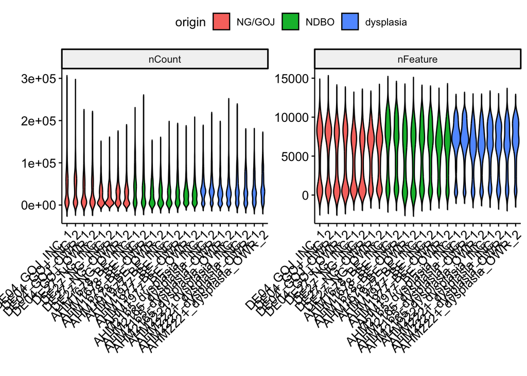

```r
df.filtered_features$Sample.ID.full <- factor(df.filtered_features$Sample.ID.full, levels = order_pdo$Sample.ID.full)

ggviolin(df.filtered_features, x = 'Sample.ID.full', y = 'value', fill = 'origin') +
  theme(legend.position = 'top', axis.text.x = element_text(angle = 45, vjust = 1, hjust=1)) + labs(x = '', y = '') +
  facet_wrap(~Feature, ncol=3, scales = 'free')
```

We can infer from this that each organoid possesses a fair chunk of low-feature cells (likely ambient RNA), and whilst this appears slightly enriched in gastric organoids, it is not specific. Additionally, feature counts are expected to be relatively high for OCM-processed data.

We should also check mitochondrial content.

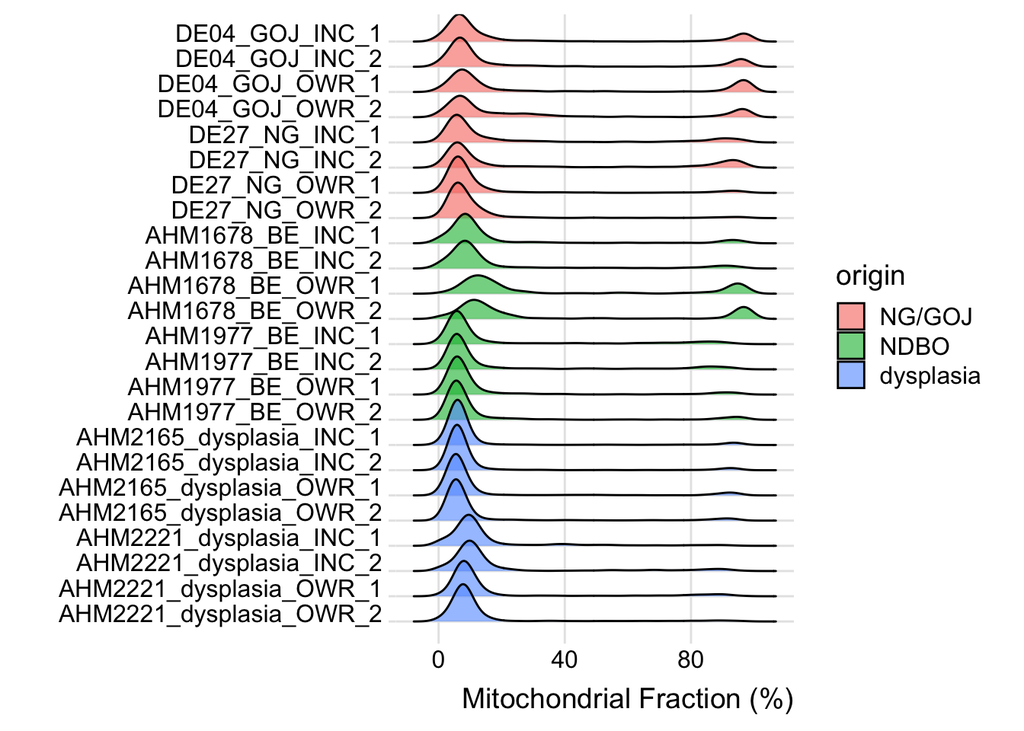

```r
# Calculate mitochondrial fraction
se.filtered$percent.mt <- PercentageFeatureSet(se.filtered, pattern = "^MT-")

df.filtered_mito <- data.frame(
  orig.ident = se.filtered$Cell.ID,
  Sample.ID.full = factor(se.filtered$Sample.ID.full),
  origin = se.filtered$Origin,
  mito_fraction = se.filtered$percent.mt
) %>%
  mutate(origin = sapply(origin, function(x) ifelse(x %in% c('NG','GOJ'), 'NG/GOJ',x))) %>%
  mutate(origin = factor(origin, levels = c('NG/GOJ','NDBO','dysplasia')),
         Sample.ID.full = factor(Sample.ID.full, levels = order_pdo$Sample.ID.full[24:1]))

ggplot(df.filtered_mito, aes(x = mito_fraction, y = Sample.ID.full, fill = origin)) +
  geom_density_ridges(alpha = .6) + theme_ridges() +
  labs(x = 'Mitochondrial Fraction (%)', y = '')
```

These organoids look good with respect to mitochondrial fraction. So, we will filter the cohort to include cells with minimum feature counts of 1500 and maximum mitochondrial fraction of 25%.

```r
# Filter data
se.filtered <- subset(se.filtered, subset = nFeature_RNA > 1500 & percent.mt < 25)

print(paste0('Total cells included: ',ncol(se.filtered)))
```

```
## [1] "Total cells included: 26583"
```

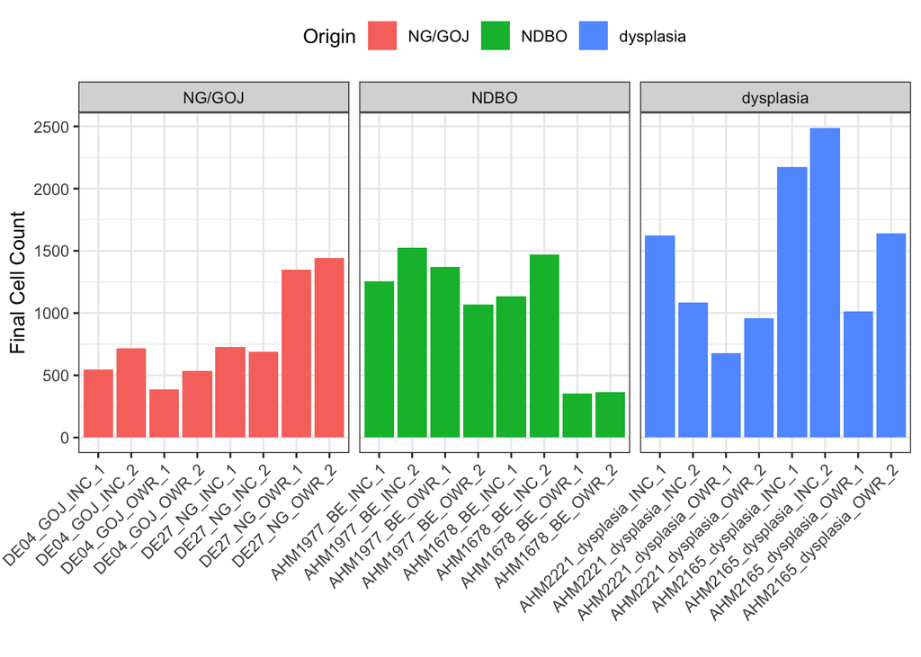

```r
# Check cell count distributions by organoid
df.cell_counts <- data.frame(table(se.filtered$Sample.ID.full)); names(df.cell_counts) <- c('Sample.ID.full','cell_count')
df.cell_counts$Sample.ID.full <- factor(df.cell_counts$Sample.ID.full, levels = order_pdo$Sample.ID.full)

# Fix order of samples
df.cell_counts$PatientID <- sapply(as.character(df.cell_counts$Sample.ID.full), function(x) strsplit(x,split='_')[[1]][1])
df.cell_counts$PatientID <- factor(df.cell_counts$PatientID,
                                   levels = c('DE04','DE27','AHM1977','AHM1678','AHM2221','AHM2165'))
df.cell_counts <- df.cell_counts %>% arrange(PatientID)
df.cell_counts$Sample.ID.full <- factor(df.cell_counts$Sample.ID.full,
                                        levels = df.cell_counts$Sample.ID.full)

df.cell_counts$Origin <- sapply(as.character(df.cell_counts$Sample.ID.full), function(x) strsplit(x,split='_')[[1]][2])
df.cell_counts$Origin[df.cell_counts$Origin == 'BE'] <- 'NDBO'
df.cell_counts$Origin <- sapply(df.cell_counts$Origin, function(x) ifelse(x %in% c('NG','GOJ'), 'NG/GOJ',x))
df.cell_counts$Origin <- factor(df.cell_counts$Origin, levels = c('NG/GOJ','NDBO','dysplasia'))

ggplot(df.cell_counts, aes(x = Sample.ID.full, y = cell_count, fill = Origin)) + theme_bw() +
  geom_bar(stat = 'identity') + facet_wrap(~Origin, scales = 'free_x', nrow=1, space = 'free_x') +
  theme(legend.position = 'top',axis.text.x = element_text(angle = 45, vjust = 1, hjust=1)) +
  labs(x = '', y = 'Final Cell Count')
```

Whilst these cell counts are lower than expected, they are generally in line with expected counts given viabilities.

# 3 Clustering and Cell Type Annotation

## 3.1 Clustering and normalisation

To begin we can do data normalisation and scaling, before running Harmony to correct for similar cell populations present across patient IDs/match with chips.

```r
# Normalisation, feature selection, and scaling
se.filtered <- NormalizeData(se.filtered) # log-normalisation
```

```
## Normalizing layer: counts
```

```r
se.filtered <- FindVariableFeatures(se.filtered, selection.method = "vst", nfeatures = 2000)
```

```
## Finding variable features for layer counts
```

```r
se.filtered <- ScaleData(se.filtered)
# Perform linear deminsionality reduction
se.filtered <- RunPCA(se.filtered, features = VariableFeatures(object = se.filtered))
```

```
## PC_ 1
## Positive:  PCLAF, ZWINT, UBE2T, STMN1, TK1, CENPM, RANBP1, MKI67, TOP2A, DTYMK
##     MAD2L1, KIF20B, CEP55, TUBB, CDKN3, TUBA1B, TPX2, TYMS, RRM2, SMC2
##     CDK1, SMC4, HMGN2, HMGB2, CKS1B, UBE2C, AURKB, H2AZ1, CDC20, H2AX
## Negative:  PSCA, CYP3A5, MUC1, RNASE1, PIGR, PNRC1, VSIG2, SLPI, PRKN, GSN
##     TFF2, TCN1, TNFSF15, LDHB, TXNIP, KCNK1, BCAS1, ANXA10, AKR1C2, NR3C2
##     RETREG1, SERPINA1, SLC6A20, CREB3L1, BTG1, UST, LINC01876, TFF1, UBE2E2, ACER2
## PC_ 2
## Positive:  DCBLD2, INPP4B, LINC02055, PLK2, IGFL2-AS1, ALDH1A3, NALF1, S100A4, CDH11, MDFIC
##     TNFAIP2, UCA1, LINC00370, HDAC9, ITGB8, QKI, KRT23, LOXL4, FHOD3, NRCAM
##     MCC, MUC16, TGM2, RND3, RARRES1, PMAIP1, TACSTD2, RNF19A, KYNU, CAV1
## Negative:  LYZ, TFF1, CYSTM1, CA2, TFF2, CLDN18, GSTM3, IGFBP2, GPX2, VSIG1
##     AGR2, CREB3L1, ANXA10, SMIM24, MUC5AC, SAMD5, MSMB, FBXO2, TTTY14, CAPN8
##     SNRPN, ST6GALNAC3, TM4SF5, ANG, SPINK1, FOXA3, AKR7A3, UGT1A1, FAM3B, ONECUT3
## PC_ 3
## Positive:  CEACAM5, TMEM45B, LGALS4, GCNT3, PRSS3, MMP28, FAM3D, KLK11, FGFBP1, BOK-AS1
##     REG4, LINC02432, PPP1R1B, POF1B, ID1, WDR72, SLPI, RAB3B, GABRP, GPX3
##     VIL1, TSPAN8, TMEM54, SLC16A5, AGR3, MUC13, MGLL, IFITM2, CLRN3, S100P
## Negative:  CLDN18, PIK3C2G, FADS2, SPART, TUSC3, CADM1, HS3ST5, SNRPN, GLIS3, PROM1
##     RNASE1, MSMB, MUC6, FUT9, IGFBP2, GPRC5B, NAV2, LGR5, PLOD2, TENT5C
##     PPP1R9A, ARL4C, PGC, ADGRL2, UBE2E2, ROBO1, DUSP5, FYN, SPINK1, GALNT13
## PC_ 4
## Positive:  MIR31HG, DCBLD2, LINC02055, NALF1, ANO1, FRMD5, MGMT, LINC01876, CDH11, TIAM1
##     SORBS2, KLK7, TGM2, S100A4, CASK, LINC00472, NRCAM, LINC02331, GLIS3, RMST
##     ALDH1A3, LOXL4, KLK6, LINC00540, TIMP3, FADS1, PROM1, BEX3, MCC, ATP10A
## Negative:  NR1D1, GADD45B, KLF10, PPP1R15A, UPP1, GADD45G, TNFAIP3, ATF3, ADM, CXCL2
##     PER1, RGS16, G0S2, CIART, TMEM70, KLF11, MYLIP, BHLHE40, GRIN1, H4C8
##     SLC3A2, DDIT3, GEM, PPP1R3C, OSER1, MAFF, RRAGD, PIM3, ZBTB2, TBC1D22A-DT
## PC_ 5
## Positive:  CASC9, PYGL, SLC14A1, CADPS, CASK, POU6F2, LINC00278, CTB-1I21.1, KCNK1, GATA2-AS1
##     LINC02832, AKR1C2, GUCY1A1, UTY, AKR1C1, HSD17B2, RHOU, LINC02474, SPINK4, RARRES1
##     OLFM2, IDH2, QKI, MAN1A1, FRY, FAM169A, F5, NMNAT2, PLBD1, EIF1AY
## Negative:  S100A14, XIST, IFI27, CEACAM6, CDKN2A, KLK10, BOK-AS1, PURPL, CT83, PHLDA2
##     IFITM2, RHOBTB3, TFF3, SCEL, LINC00960, FGFBP1, SEMA3A, XRCC4, RAB3B, UPK1B
##     CLIP4, IGSF1, KLK6, AGR2, CALD1, KLK11, ITGBL1, WDR72, KLK7, ARHGDIB
```

```r
# Run harmony and run dimensional reduction
se.harmony <- se.filtered
se.harmony <- RunHarmony(se.harmony, 'Patient.ID')
```

```
## Transposing data matrix
```

```
## Using automatic lambda estimation
```

```
## Thetas: 2
```

```
## Initializing state using k-means centroids initialization
```

```
## Initializing centroids
```

```
## Harmony 1/10
```

```
## Harmony 2/10
```

```
## Harmony 3/10
```

```
## Harmony 4/10
```

```
## Harmony converged after 4 iterations
```

```r
se.harmony <- RunUMAP(se.harmony, reduction = 'harmony', dims=1:15)
```

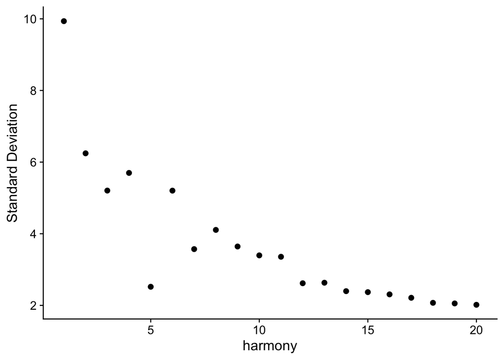

```r
# Find Neighbours and clusters
ElbowPlot(se.harmony, reduction = 'harmony') # 12 clusters looks optimal
```

```r
se.harmony <- FindNeighbors(se.harmony, dims = 1:15, reduction = 'harmony')
se.harmony <- FindClusters(se.harmony, resolution = .48, reduction = 'harmony')
```

```
## Modularity Optimizer version 1.3.0 by Ludo Waltman and Nees Jan van Eck
##
## Number of nodes: 26583
## Number of edges: 859724
##
## Running Louvain algorithm...
## Maximum modularity in 10 random starts: 0.8947
## Number of communities: 12
## Elapsed time: 3 seconds
```

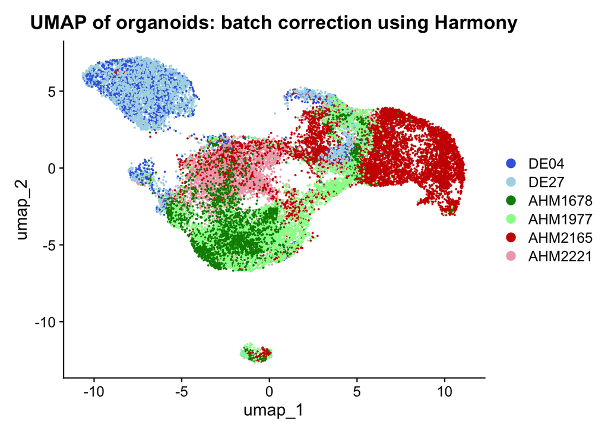

```r
se.harmony$Patient.ID <- factor(se.harmony$Patient.ID,
                                levels = c('DE04','DE27','AHM1678','AHM1977','AHM2165','AHM2221'))
DimPlot(se.harmony, reduction = 'umap', group.by = 'Patient.ID') +
  ggtitle('UMAP of organoids: batch correction using Harmony') +
  scale_color_manual(values = c('royalblue','lightblue','green4','palegreen','red3','pink2'))
```

We should also check representation of cell types clusters across patients.

```r
clusters_vs_patients <- data.frame(
  Cluster = se.harmony$seurat_clusters,
  Patient = se.harmony$Patient.ID,
  Sample = se.harmony$Sample.ID.full,
  Treatment = sapply(se.harmony$Treatment, function(x) strsplit(x,split='_')[[1]][1])
) %>%
  group_by(Patient, Cluster, Treatment) %>% summarise(n=n())
```

```
## `summarise()` has regrouped the output.
## ℹ Summaries were computed grouped by Patient, Cluster, and Treatment.
## ℹ Output is grouped by Patient and Cluster.
## ℹ Use `summarise(.groups = "drop_last")` to silence this message.
## ℹ Use `summarise(.by = c(Patient, Cluster, Treatment))` for per-operation
##   grouping (`?dplyr::dplyr_by`) instead.
```

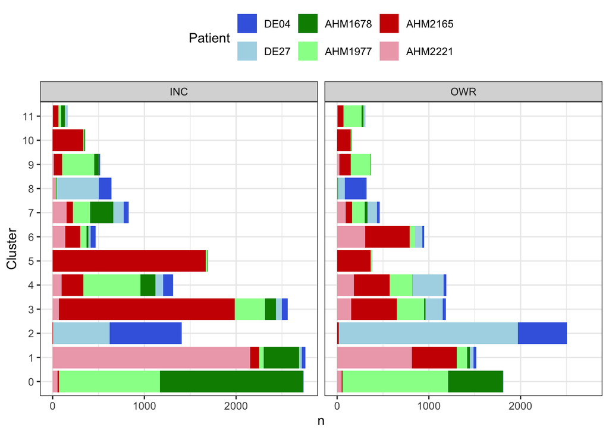

```r
ggplot(clusters_vs_patients, aes(x = Cluster, y = n, fill = Patient)) + theme_bw() +
  geom_bar(stat = 'identity') + theme(legend.position = 'top') +
  coord_flip() +
  scale_fill_manual(values = c('royalblue','lightblue','green4','palegreen','red3','pink2')) +
  facet_wrap(~Treatment)
```

## 3.2 Defining cell types

The rigorous part of the cell type definitions has been conducted off-Rmarkdown, so the purposes here are simply to demonstrate alignment between our labels and the relevant markers.

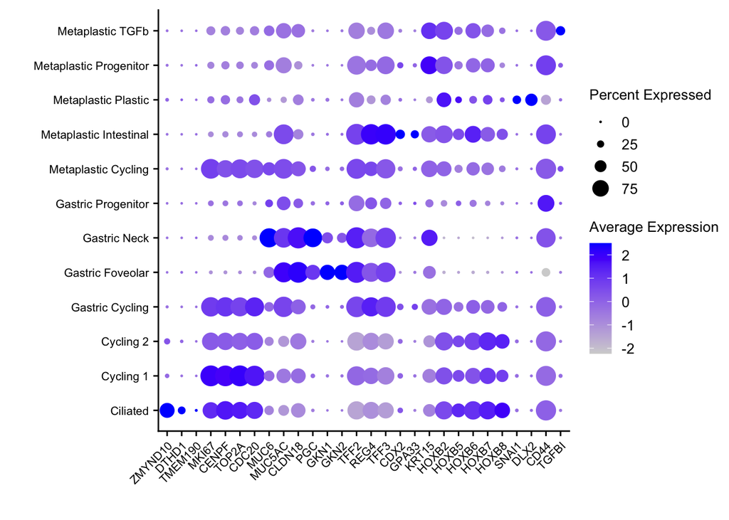

```r
cluster.ids = c('Metaplastic Progenitor','Metaplastic Intestinal','Gastric Neck','Cycling 1','Metaplastic Cycling','Cycling 2','Gastric Cycling','Gastric Progenitor','Gastric Foveolar','Metaplastic TGFb','Ciliated','Metaplastic Plastic')

# cluster.ids = c('Metaplastic Intestinal','Gastric Neck','Metaplastic Progenitor','Cycling 1', 'Metaplastic Cycling','Cycling 2',
#                 'Gastric Progenitor','Metaplastic TGFb','Ciliated','Metaplastic Plastic','Gastric Intermediate','Gastric Foveolar')
se.harmony$Cluster = factor(cluster.ids[as.numeric(se.harmony$seurat_clusters)])

# Generate a dotplot here consisting of relevant markers
markers.ciliated <- c('ZMYND10','DTHD1','TMEM190')
markers.cycling <- c('MKI67','CENPF','TOP2A','CDC20')
markers.gastric <- c('MUC6','MUC5AC','CLDN18','PGC','GKN1','GKN2','TFF2')
markers.intestinal <- c('REG4','TFF3','CDX2','GPA33')
markers.metaplastic <- c('KRT15','HOXB2','HOXB5','HOXB6','HOXB7','HOXB8')
markers.metaplastic_others <- c('SNAI1','DLX2','CD44','TGFBI') # this includes EMT, stem, and TGFb

DotPlot(se.harmony,
        features = c(markers.ciliated, markers.cycling, markers.gastric,
                     markers.intestinal, markers.metaplastic, markers.metaplastic_others),
        group.by = 'Cluster') +
  theme(axis.text.x = element_text(angle = 45, vjust = 1, hjust=1, size = 8),
        axis.text.y = element_text(size = 8),
        legend.title = element_text(size = 10), legend.text = element_text(size = 10)) +
  labs(x='', y='')
```

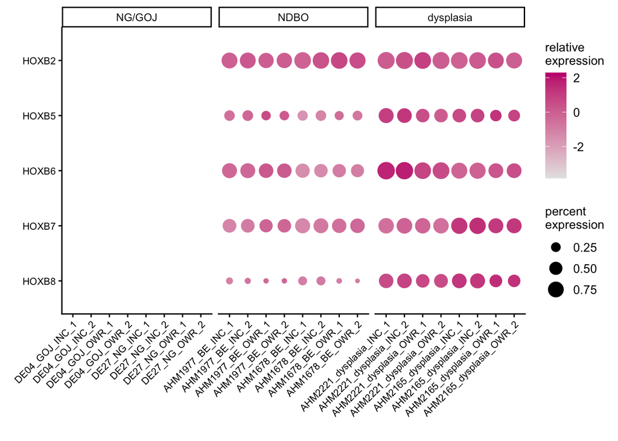

```r
# We would also like to demonstrate how mucin expression varies across normal->dysplasia
se.harmony$Origin <- sapply(se.harmony$Origin, function(x) ifelse(x %in% c('NG','GOJ'), 'NG/GOJ',x))
se.harmony$Origin <- factor(se.harmony$Origin, levels = c('NG/GOJ','NDBO','dysplasia'))
se.harmony$Sample.ID.full <- factor(se.harmony$Sample.ID.full, levels = levels(df.cell_counts$Sample.ID.full))

dittoSeq::dittoDotPlot(se.harmony, vars = paste0('HOXB',c(8:5,2)),
                       group.by = "Sample.ID.full", split.by = "Origin",
                       split.adjust = list(scales = "free_x", space = "free_x")) +
  theme(axis.text.x = element_text(angle = 45, vjust = 1, hjust=1, size = 8),
        axis.text.y = element_text(size = 8),
        legend.title = element_text(size = 10),
        legend.text = element_text(size = 10)) +
    labs(x='', y='') + coord_flip()
```

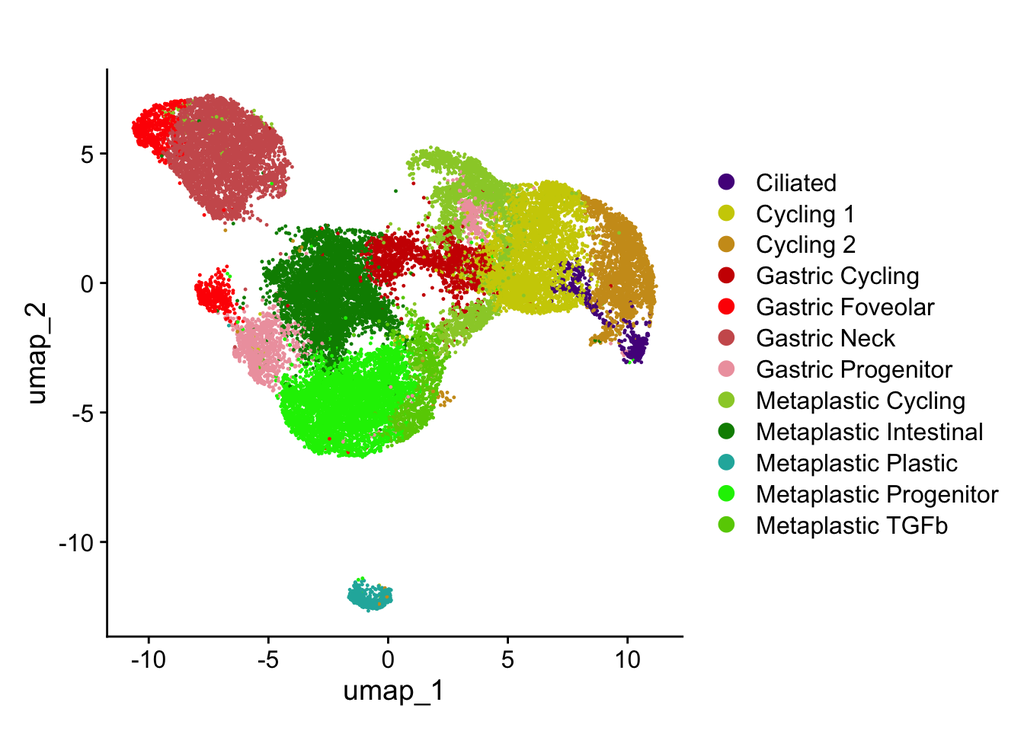

```r
# Then demonstrate concordance in a UMAP
cluster_cols <- c('purple4','yellow3','goldenrod3','red3','red','indianred','lightpink2',
                  'yellowgreen','green4','lightseagreen','green2','chartreuse3') # green2 was green3
DimPlot(se.harmony, reduction = 'umap', group.by = 'Cluster') +
  scale_color_manual(values = cluster_cols) +
  ggtitle('')
```

```r
# Finally, demonstrate distributions across organoids
df.cluster_pdo <- data.frame(
  Cluster = se.harmony$Cluster,
  Organoid = se.harmony$Sample.ID.full,
  Origin = as.character(se.harmony$Origin),
  Patient = se.harmony$Patient.ID,
  Treatment = se.harmony$Treatment
) %>%
  # mutate(Origin = factor(Origin, levels = c('NG','GOJ','NDBO','dysplasia'))) %>%
  # arrange(Origin, Patient, Treatment) %>%
  # mutate(Origin = sapply(as.character(Origin), function(x) ifelse(x %in% c('NG','GOJ'), 'NG/GOJ',x))) %>%
  # mutate(Origin = factor(Origin, levels = c('NG/GOJ','NDBO','dysplasia'))) %>%
  group_by(Cluster, Organoid, Origin) %>% summarise(cell_count = n())
```

```
## `summarise()` has regrouped the output.
## ℹ Summaries were computed grouped by Cluster, Organoid, and Origin.
## ℹ Output is grouped by Cluster and Organoid.
## ℹ Use `summarise(.groups = "drop_last")` to silence this message.
## ℹ Use `summarise(.by = c(Cluster, Organoid, Origin))` for per-operation
##   grouping (`?dplyr::dplyr_by`) instead.
```

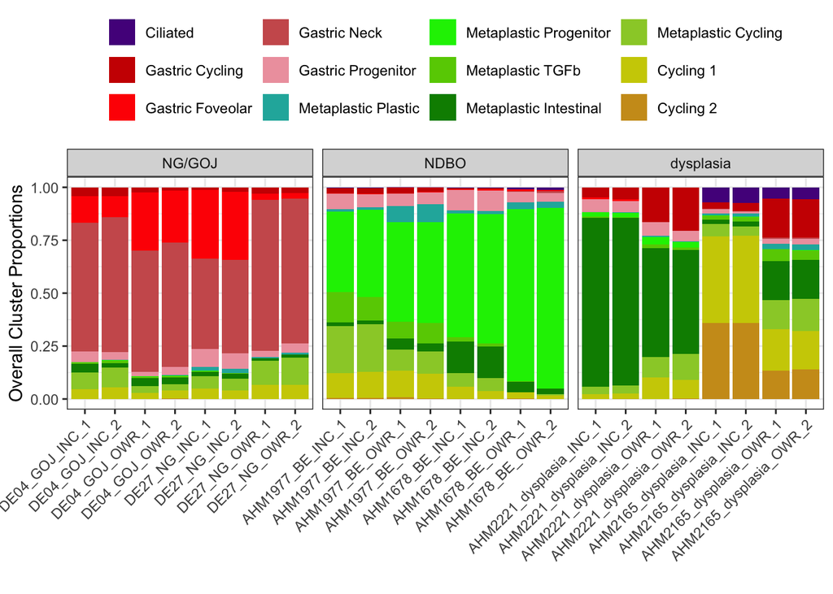

```r
# Get index for reordering of clusters
cluster.names <- sort(unique(df.cluster_pdo$Cluster)) %>% as.character
cluster.index <- c(1,4:7,10:12,9:8,2:3)

df.cluster_pdo$Cluster <- factor(df.cluster_pdo$Cluster, levels = cluster.names[cluster.index])

df.cluster_pdo$Origin <- factor(df.cluster_pdo$Origin, levels = c('NG/GOJ','NDBO','dysplasia'))
ggplot(df.cluster_pdo, aes(x = Organoid, y = cell_count, fill = Cluster)) +
  theme_bw() + geom_bar(stat = 'identity', position = 'fill') +
  facet_wrap(~Origin, nrow=1, scales = 'free_x', space='free_x') +
  theme(legend.position = 'top', legend.title = element_blank(),
        axis.text.x = element_text(angle = 45, vjust = 1, hjust=1)) +
  labs(x = '', y = 'Overall Cluster Proportions')  +
  scale_fill_manual(values = cluster_cols[cluster.index])
```

From this, we can see that, as expected, NG- and GOJ-derived organoids are strongly represented by normal gastric cells (specifically basal and foveolar, though leaning towards basal), BE organoids are characterised by metaplastic cells (i.e. those positive for gastric and intestinal markers), and dysplastic organoids are characterised either by cycling cells or by metaplastic cells (this particular metaplastic cluster is defined primarily by strong intestinal phenotype).

We also see that AHM2165 is defined strongly by cycling cells. This organoid was derived from a highly dysplastic region, including mutations in TP53 and ARID1A, chromosomal instability (defined by changes from diploid) and genomic instability). Whilst AHM2221 appears to carry a TP53 mutation and increased TMB, it harbours fewer driver alterations and is decidedly diploid, explaining its maintained metaplastic identity.

## 3.3 Comparison of cell types across culture media

We can demonstrate where there may be discrepancies in cell types represented in the organoid based on culture media.

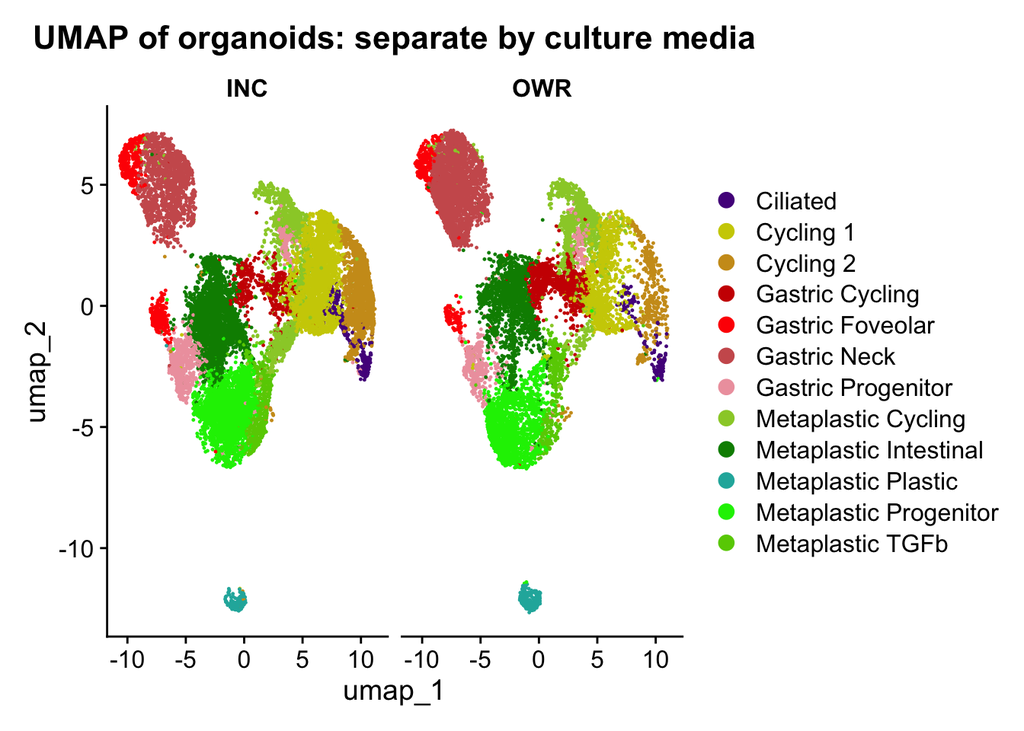

```r
# UMAP plots separated by media (highlights reduced representation of cycling cells with OWR)
DimPlot(se.harmony, reduction = 'umap', group.by = 'Cluster', split.by = 'Treatment')  +
  scale_color_manual(values = cluster_cols) +
  ggtitle('UMAP of organoids: separate by culture media')
```

```r
# Summarise and quantify cell type proportions
df.cluster_treatment <- data.frame(
  Cluster = se.harmony$Cluster,
  Treatment = se.harmony$Treatment
) %>%
  group_by(Cluster, Treatment) %>% summarise(cell_count=n())
```

```
## `summarise()` has regrouped the output.
## ℹ Summaries were computed grouped by Cluster and Treatment.
## ℹ Output is grouped by Cluster.
## ℹ Use `summarise(.groups = "drop_last")` to silence this message.
## ℹ Use `summarise(.by = c(Cluster, Treatment))` for per-operation grouping
##   (`?dplyr::dplyr_by`) instead.
```

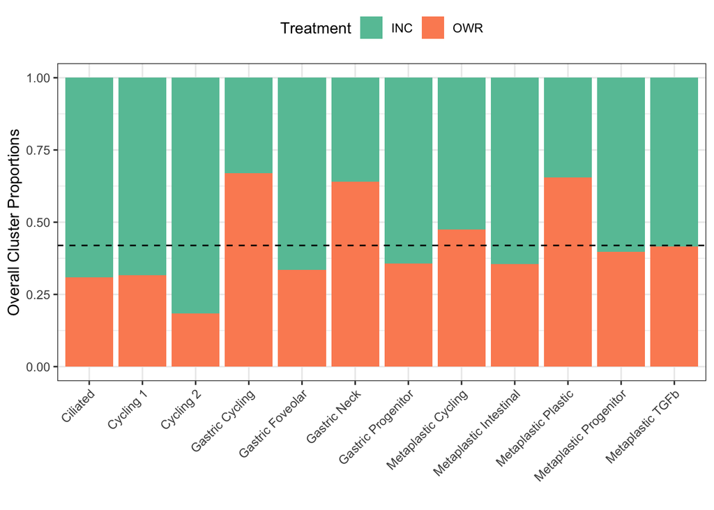

```r
ggplot(df.cluster_treatment, aes(x = Cluster, y = cell_count, fill = Treatment)) +
  theme_bw() + geom_bar(stat = 'identity', position = 'fill') +
  geom_hline(col = 'black', linetype = 'dashed',
             yintercept = sum(se.harmony$Treatment == 'OWR')/length(se.harmony$Treatment)) + # this line represents the overall proportion of cells derived from OWR-treated organoids, to act as a reference
  theme(legend.position = 'top', axis.text.x = element_text(angle = 45, vjust = 1, hjust=1)) +
  labs(x = '', y = 'Overall Cluster Proportions') +
  scale_fill_brewer(palette = 'Set2')
```

As shown from both the UMAP and summary barplot, the INC media appears to better support cycling cells, whilst gastric basal (the largest normal gastric cell cluster) is supported better by OWR media.

## 3.4 Cell Cycle Scoring

Finally, we wanted to to further check differences between the cycling and metaplastic clusters. In particular, the two cycling clusters are most strongly represented in AHM2165 organoids, although whilst ‘Cycling 2’ appears unique to these organoids, ‘Cycling 1’ is somewhat represented across organoids.

To check this, we can see what stages of the cell cycle these cells tend to appear in.

```r
# Define cell cycle scores
se.harmony <- CellCycleScoring(
  se.harmony,
  g2m.features = cc.genes.updated.2019$g2m.genes,
  s.features = cc.genes.updated.2019$s.genes
)
# Summarise cell counts
df.cycling_phase <- data.frame(
  Cluster = se.harmony$Cluster,
  CellCyclePhase = se.harmony$Phase

) %>%
  # dplyr::filter(grepl(pattern = 'Cycling', Cluster) |
  #          grepl(pattern = 'Metaplastic', Cluster)) %>%
  group_by(Cluster, CellCyclePhase) %>% summarise(cell_count=n())
```

```
## `summarise()` has regrouped the output.
## ℹ Summaries were computed grouped by Cluster and CellCyclePhase.
## ℹ Output is grouped by Cluster.
## ℹ Use `summarise(.groups = "drop_last")` to silence this message.
## ℹ Use `summarise(.by = c(Cluster, CellCyclePhase))` for per-operation grouping
##   (`?dplyr::dplyr_by`) instead.
```

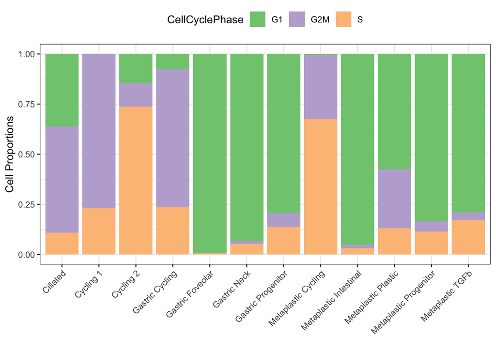

```r
ggplot(df.cycling_phase, aes(x = Cluster, y = cell_count, fill = CellCyclePhase)) +
  theme_bw() + geom_bar(stat = 'identity', position = 'fill') +
  theme(axis.text.x = element_text(angle = 45, vjust = 1, hjust=1),
        legend.position = 'top') +
  labs(x = '', y = 'Cell Proportions') +
  scale_fill_brewer(palette = 'Accent')
```

It appears that cell cycle stage is a strong differentiator of the two cycling clusters, with ‘Cycling 1’ defined primarily by G2/M, and ‘Cycling 2’ by S phase. This also highlights how the ‘Metaplastic Cycling’ cluster shows similarities with the AHM2165 cycling cells, given representation of G2/M and S-phase cells.